# Regression and Classification Trees

Rob Williams

11/15/0217

Let’s apply these techniques to a subject that I know nothing about: differences in voting by economic status across the world. Read in the datafile `votes.RData`, which is a subset of the data contained in Kasara and Suryanarayan (2015).[^1] These data[^2] provide an excellent illustration of some of the benefits of tree methods. Due to their small sample size of 211, the authors have to run 6 separate regressions to test each of their proposed explanations in turn. With a tree-based approach, we can include all 6 explanatory variables, and controls, in a single analysis and explore how much explanatory power each contributes.

```r
library(reshape2) # reshaping data for plots
library(ggplot2) # plots

# source custom ggplot theme
source('https://raw.githubusercontent.com/Jieli12/RWmisc/master/theme_rw.R')

# load data
load('votes.RData')

# split into test and training data
train <- sample(1:nrow(votes), (2 / 3) * nrow(votes))
votes_train <- votes[train, ]
votes_test <- votes[-train, ]
```

The first variable in the data is the estimated $\beta_j$ effect of income on turnout. The next six are the theoretically driven explanatory variables: voting polarization, electoral distance between the top and bottom income quintiles, bureaucratic quality, government effectiveness, direct tax revenue, and log GDP per capita. The remaining variables are the controls: proportional representation, concurrent elections, compulsory voting, polity score, infant mortality, gross gini coefficient, homicide rate, and ethnic fractionalization.

All of these methods select which predictors to include and which to exclude in a model. Some of them even allow for $n$-way interactions and $n^{th}$ order polynomials. This can result in very complex models where it is difficult to recover the marginal effect of a specific variable. If we were using synethic data and controlled the data generating process, we could compare the choices made by these models to true DGP. When working with real data, we don’t have this option. We thus rely on predictive accuracy as a measure of model fit. Many packages use mean squared error (MSE) as their metric of fit.
$$\begin{align} \frac{1}{n}\sum_{i=1}^{n} \left(\hat{Y_i} - Y_i
\right)^2 \end{align}$$
Some packages don’t directly provide a MSE, but they all allow us to calculate predicted $\hat{y}$s from our test data, and we can then compute MSE ourselves. Let’s go ahead and make a function to calculate MSE because we’re going to be doing this a lot.

```r
# calculate mean squared error
mse <- function(y, yhat) {

  mean((yhat - y)^2)

}
```

## Single Tree Approaches

The `tree` package is a little outdated and doesn’t have a lot of options compared to newer packages like `rpart`, but it *does* offer some really easy plotting functions to help us understand how regression trees work.

```r
library(tree)
fit_tree <- tree(formula = beta_exp ~., data = votes_train)
summary(fit_tree)
```

```
##
## Regression tree:
## tree(formula = beta_exp ~ ., data = votes_train)
## Variables actually used in tree construction:
## [1] "gdp_pc_ln_z"       "infantmortality_z" "dtax_per_rev_z"
## [4] "homicide_z"        "VP_z"              "giniall_gross_z"
## [7] "prs2_z"            "ge_est_z"          "elec_dist_1_5_z"
## Number of terminal nodes:  18
## Residual mean deviance:  0.0043 = 0.52 / 122
## Distribution of residuals:
##    Min. 1st Qu.  Median    Mean 3rd Qu.    Max.
##  -0.132  -0.041  -0.004   0.000   0.042   0.167
```

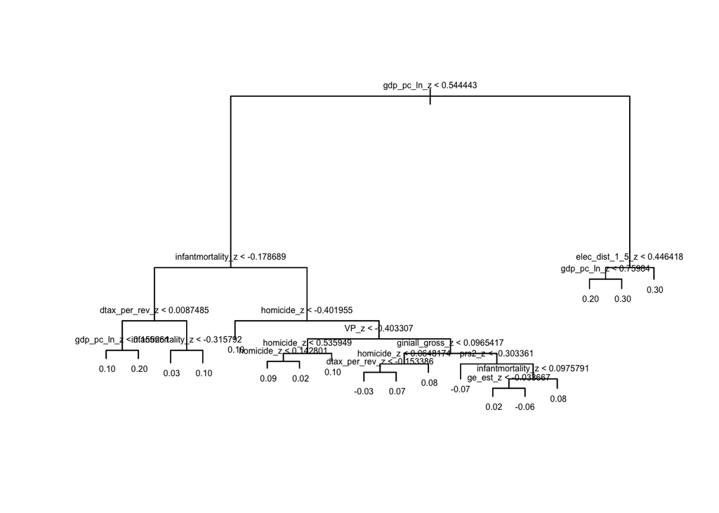

```r
# need to execute these as part of the same command
plot(fit_tree); text(fit_tree, cex = .5)
```

```r
fit_tree$frame
```

| var | n | dev | yval | splits |
| --- | --- | --- | --- | --- |
| gdp_pc_ln_z | 140 | 1.7531 | 0.0896 |  |
| infantmortality_z | 118 | 1.0500 | 0.0631 |  |
| dtax_per_rev_z | 36 | 0.2088 | 0.1192 |  |
| gdp_pc_ln_z | 20 | 0.0471 | 0.1640 |  |
|  | 8 | 0.0051 | 0.1208 |  |
|  | 12 | 0.0171 | 0.1929 |  |
| infantmortality_z | 16 | 0.0712 | 0.0631 |  |
|  | 10 | 0.0169 | 0.0251 |  |
|  | 6 | 0.0157 | 0.1265 |  |
| homicide_z | 82 | 0.6782 | 0.0385 |  |

[output cut: 25 more lines]

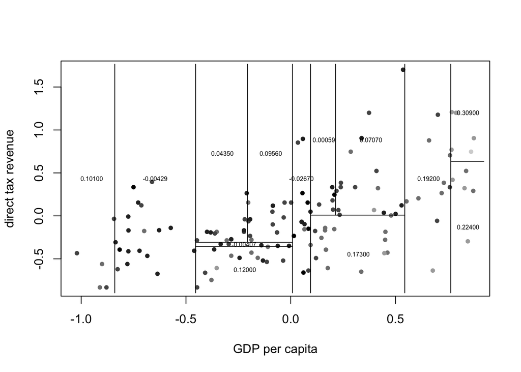

```r
fit_tree_simple <- tree(formula = beta_exp ~ gdp_pc_ln_z + dtax_per_rev_z,
                        data = votes_train)
plot(x = votes_train$gdp_pc_ln_z, y = votes_train$dtax_per_rev_z,
     col = grey(seq(0, 1, length.out = 7))[findInterval(votes_train$beta_exp,
                                                        seq(min(votes_train$beta_exp),
                                                            max(votes_train$beta_exp),
                                                            length.out = 7))], pch = 20,
     xlab = 'GDP per capita', ylab = 'direct tax revenue')
partition.tree(fit_tree_simple, add = T, cex = .5)
```

We can see where each of the countries in the training dataset fall along the two variables used in our decision tree, and each square represents a leaf at the bottom of the tree. The colors range from lightest to darkest, covering the range of $\beta_j$ in the data.

The last thing we want to do with `tree()` is see how changing the parameters of the tree algorithm can alter the resulting model. The decision of whether to grow a new node or not is controlled by a number of parameters, but let’s focus on the `mindev` argument. This determines how much a potential node must reduce the error for the algorithm to grow a new node. The default value is .01. Try setting it to something larger and plotting the resulting tree.

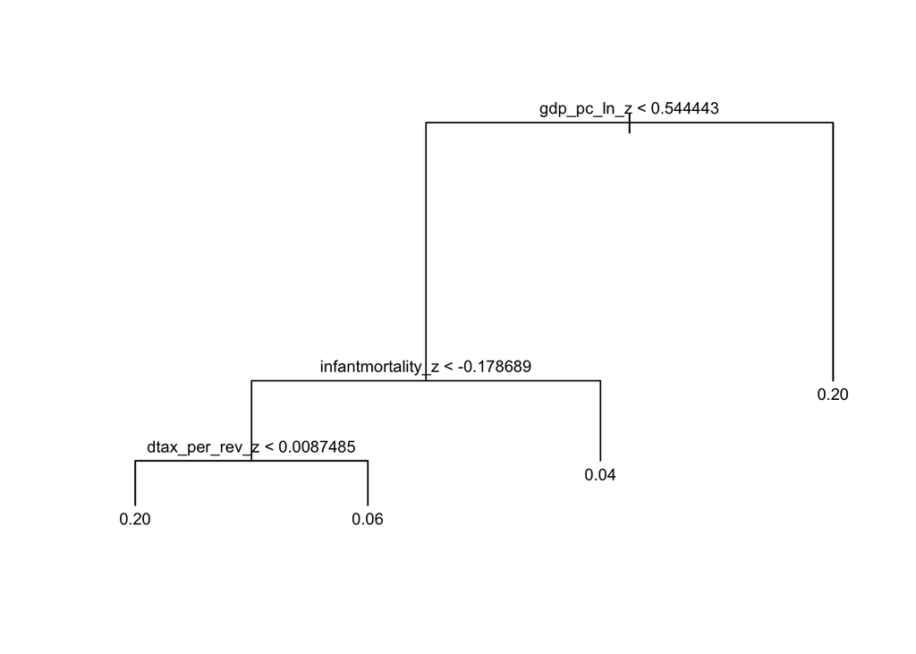

```r
fit_tree <- tree(beta_exp ~., data = votes_train, mindev = .05)
plot(fit_tree); text(fit_tree, cex = .75)
```

```r
fit_tree$frame[which(fit_tree$frame$var == '<leaf>'), 'yval']
```

```
## [1] 0.164 0.063 0.038 0.231
```

```r
pred_tree <- predict(fit_tree, votes_test)
```

Load up `rpart` and take a look at the main function, which is called – surprisingly enough – `rpart()`.

```r
library(rpart)
fit_rpart <- rpart(formula = beta_exp ~., data = votes_train, method = 'anova')
```

Just like with `tree()`, we can plot the resulting tree to see where our model is making decisions.

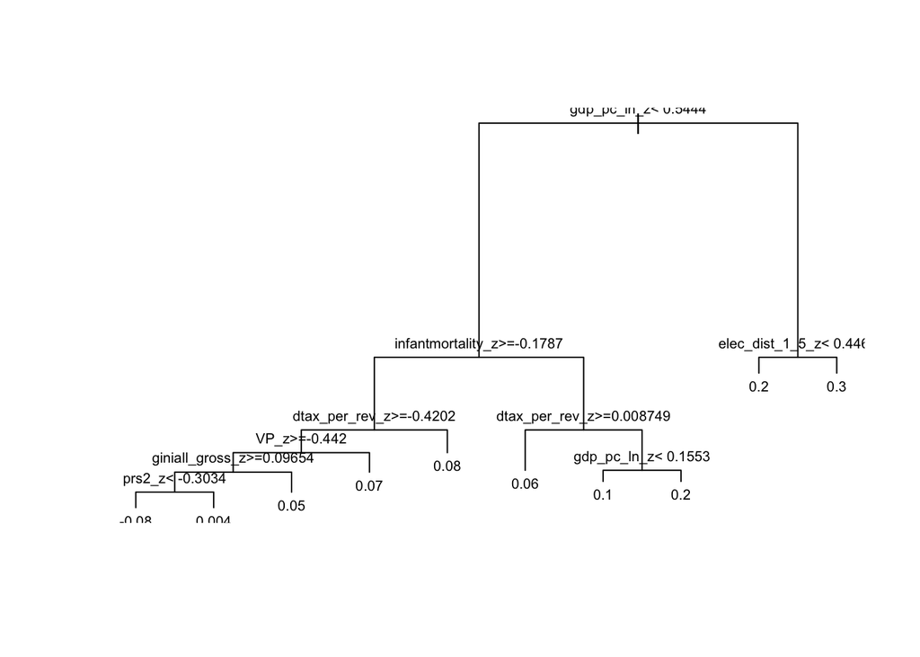

```r
plot(fit_rpart); text(fit_rpart, cex = .65)
```

We can `prune` an `rpart` fit object by supplying a complexity parameter. Pruning a tree removes branches farther down the tree which do not sufficiently increase the fit by the complexity parameter. For anova trees, the complexity parameter is $R^2$. We can also define a complexity parameter in `rpart()` when fitting a tree. Try pruning your tree using a complexity parameter larger than the default of .01. This latter tree will be simpler because the higher complexity parameter penalizes potential splits that do not sufficiently increase the fit of the model.

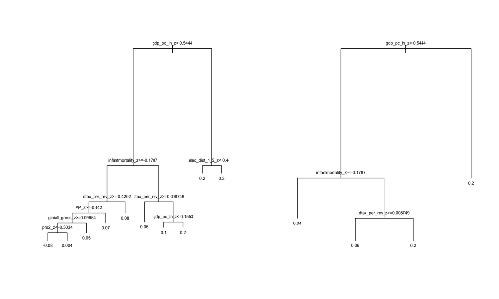

```r
par(mfrow = c(1, 2))
plot(fit_rpart); text(fit_rpart, cex = .5)
plot(prune(fit_rpart, cp = .033)); text(prune(fit_rpart, cp = .033), cex = .5)
```

```r
par(mfrow = c(1, 1))
```

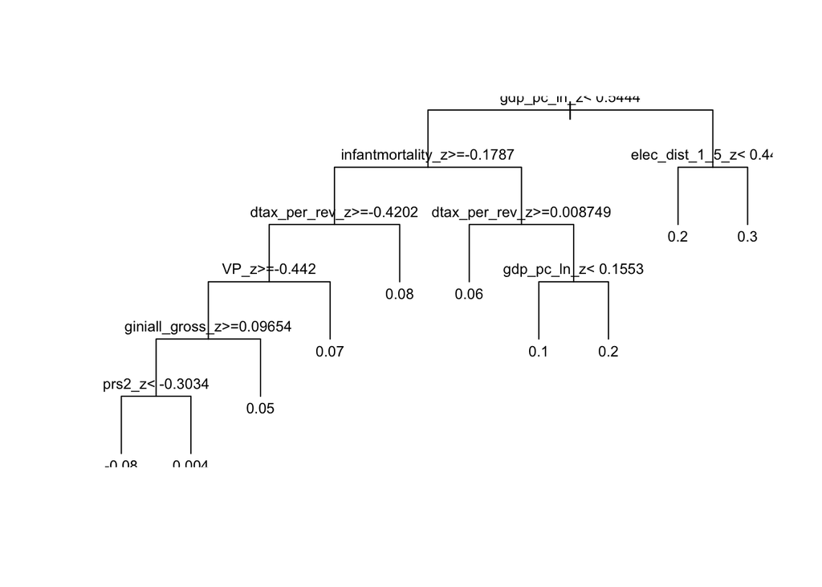

```r
plot(prune(fit_rpart, cp = .005), uniform = T); text(prune(fit_rpart, cp = .005),
                                                     cex = .75)
```

Keep in mind that overfitting is just as much of a concern here as it is in the linear model context. We could fit a tree with a complexity parameter of .00001, but it would have a huge number of branches, and would probably fare poorly in out of sample prediction. Try this out for yourself, and compare the MSE for complexity parameters ranging from .1 to .00001.

```r
fit_rpart_of <- rpart(formula = beta_exp ~., data = votes_train, method = 'anova',
                   control = rpart.control(cp = .00001))

# combine MSE for all 5 complexity parameters into a dataframe
mse_cp <- t(data.frame(mse(predict(prune(fit_rpart_of, cp = .1),
                                   newdata = votes_test), votes_test$beta_exp),
                       mse(predict(prune(fit_rpart_of, cp = .01),
                                   newdata = votes_test), votes_test$beta_exp),
                       mse(predict(prune(fit_rpart_of, cp = .001),
                                   newdata = votes_test), votes_test$beta_exp),
                       mse(predict(prune(fit_rpart_of, cp = .0001),
                                   newdata = votes_test), votes_test$beta_exp),
                       mse(predict(fit_rpart_of, newdata = votes_test),
                           votes_test$beta_exp)))

# rename rows and columns in dataframe
colnames(mse_cp) <- 'MSE'; rownames(mse_cp) <- c('.1', '.01', '.001', '.0001', '.00001')
mse_cp
```

```
##           MSE
## .1     0.0084
## .01    0.0114
## .001   0.0112
## .0001  0.0112
## .00001 0.0112
```

```r
fit_rpart <- rpart(formula = beta_exp ~., data = votes_train, method = 'anova',
                   control = rpart.control(cp = .001))
pred_rpart <- predict(fit_rpart, votes_test, type = 'vector')
```

## Random Forests

Random forests are an ensemble technique to try and overcome some of the limitations of trees. As we saw above, trees that have grown very deep are prone to overfitting the data. An additional shortcoming of trees is that they are deterministic. Given the same parameters, an algorithm will grow an identical tree each time.

One way to try and overcome this problem is to use bootstrap aggregating, or bagging. Bagging involves drawing samples from the training data with replacement, applying the same tree algorithm to each one, and then making predictions on test data by averaging the prediction from each indivdiual tree. The prediction $f(\cdot)$ for a random forest is thus given by:

$$\begin{align} f(X_i) = \frac{1}{M}\sum_{m=1}^M T_m(X_i,\Theta_m)
\end{align}$$

where $M$ is the number of trees, $T_m$ is an individual tree, and $\Theta_m$ are the parameters that define that tree.

Where bootstrap aggregating introduces randomness just in the sampling of subsets, a random forest includes further randomness by selecting a random subset of the variables when making splitting decisions at each node. Just like bagging, a random forest makes predictions by making predictions for each tree, and then averating over them.

```r
library(randomForest)
fit_rf <- randomForest(x = votes_train[, 2:ncol(votes_train)], y = votes_train[, 1])
```

We can use the `predict()` function on random forest objects to obtain predictions from the ensemble, and then compare them to true values to assess the forest’s predictive accuracy.

```r
pred_rf <- predict(fit_rf, votes_test)
mse(pred_rf, votes_test$beta_exp)
```

```
## [1] 0.0093
```

Just like with single tree methods, we can alter the parameters of the algorithm used to grow the ensemble. Try changing some of the arguments to `randomForest` and seeing if you can improve the accuracy of the resulting ensemble. Some of the arguments may have counterintuitive effects; try increasing the minimum size of final nodes (thus decreasing the number of nodes in the tree) and see what happens to your MSE.

```r
fit_rf <- randomForest(x = votes_train[, 2:ncol(votes_train)], y = votes_train[, 1],
                       ntree = 1000, mtry = floor(ncol(votes_train)/5),
                       sampsize = ceiling(.98*nrow(votes_train)),
                       nodesize = 10)
pred_rf <- predict(fit_rf, votes_test)
mse(pred_rf, votes_test$beta_exp)
```

```
## [1] 0.0089
```

Once we’ve gotten an ensemble whose predictve power we’re happy with, we can use the `varImpPlot()` command to get a sense of which variables are contributing the most explanatory power.

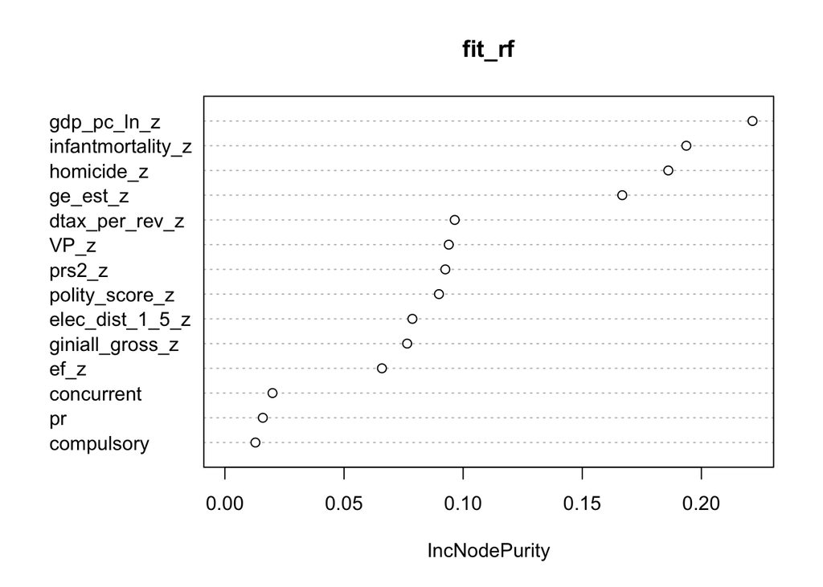

```r
varImpPlot(fit_rf)
```

## Gradient Boosting Machines

Gradient boosting machines are similar to random forests or bagging approaches, but instead of just growing a large number of trees from independent random samples of the data, we grow them sequentially on transformations of the data. For each new tree we optimize

$$\hat{\Theta}_m = \arg\min_{\Theta_m}\sum_{i=1}^N L(y_i,
f_{m-1}(X_i) + T_m (X_i; \Theta_m))$$

which can be approximated by

$$\hat{\Theta}_m = \arg\min_{\Theta_m}\sum_{i=1}^N (-g_{im} - T_m
(X_i; \Theta_m))^2$$

where $g_m$ is the gradient of the loss function $L$. Since we have a very small dataset, we want to be wary of overfitting in our ensemble. We can do this by setting the `bag.fraction` argument below the standard of .5, which means we’re training on a smaller subset of the data, and setting the `m.minobsinnode` argument below its default of 10 which is a significant portion of our data.

```r
library(gbm)
fit_gbm <- gbm(formula = beta_exp ~ ., data = votes_train, distribution = 'gaussian',
               n.trees = 1e3, cv.folds = 3, interaction.depth = 5, n.minobsinnode = 7,
               shrinkage = .001, bag.fraction = .35, keep.data = T,
               n.cores = parallel::detectCores())
```

We can easily continue growing trees from an existing `gbm` object with the `gbm.more()` function. If you didn’t set `keep.data = T` in the initial call to `gbm()`, you need to supply the data as an additional argument to `gbm.more()`. Note that `gbm.more()` does not perform cross-validation to estimate generalization error.

```r
fit_gbm <- gbm.more(object = fit_gbm, n.new.trees = 1e3)
```

We can easily make predictions from `gbm` objects with the `predict()` function, which requires us to supply the `gbm` object, our test data, and the tree(s) we wish to use to make predictions. Because gradient boosting machines are an iterative process, the `gbm` object stores all trees grown. We can use this iterative nature to visualize how the predictions for each observation evolve as the number of trees increases.

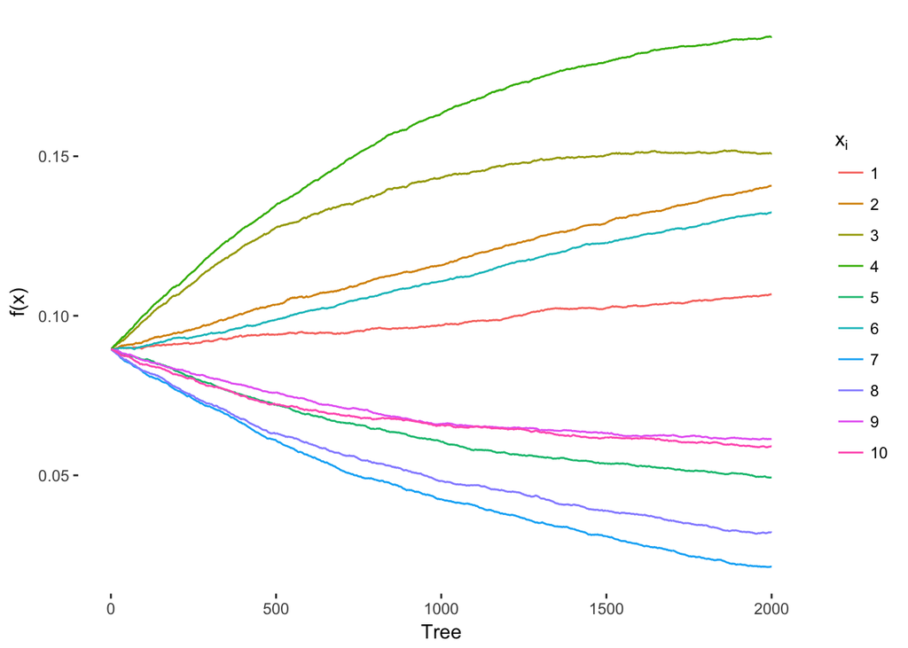

```r
# get predictions for all 2000 trees
pred_gbm_init <- predict(object = fit_gbm, newdata = votes_test, n.trees = 1:2000)

# get predictions for first 10 test observations
pred_gbm_plot <- pred_gbm_init[1:10, ]

# reshape from wide to long and plot
pred_gbm_plot <- melt(pred_gbm_plot, id.vars = 'Tree')
ggplot(pred_gbm_plot, aes(x = Var2, y = value, color = as.factor(Var1))) +
  geom_line() +
  labs(x = 'Tree', y = 'f(x)', color = expression(x[i])) +
  theme_rw()
```

This means we can also see how the mean squared error of the `gbm` object evolves as the number of trees increases.

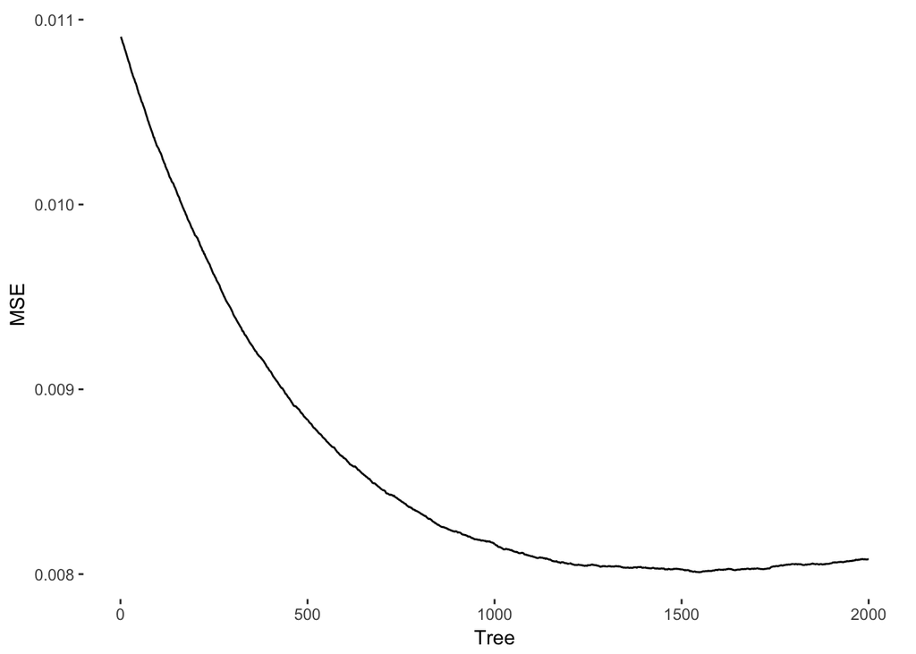

```r
gbm_mse_seq <- apply(pred_gbm_init, 2, function(x) mse(votes_test$beta_exp, x))
ggplot(data = data.frame(Tree = 1:2000, MSE = gbm_mse_seq), aes(x = Tree, y = MSE)) +
  geom_line() +
  theme_rw()
```

Looks like we have our lowest MSE somewhere in the neighborhood of tree 1500. Let’s find the tree with the actual lowest MSE and save that for our model comparison later.

```r
pred_gbm <- predict(object = fit_gbm, newdata = votes_test,
                    n.trees = which(gbm_mse_seq == min(gbm_mse_seq)))
```

## Bayesian Additive Regression Trees

Bayesian additive regression trees (BART) are similar to random forests, except they are estimated in a Bayesian statistical framework, so they are able to produce estimates of uncertainty around predictions. The model is very similar to tree bagging, except with the addition of an error:
$$\begin{align} f(X_i) = \frac{1}{M}\sum_{m=1}^M T_m(X_i,\Theta_m)
+ \epsilon_i; ~~~~ \epsilon_i \sim \mathcal{N}(0,\sigma^2)
\end{align}$$
The model places independent priors over all the parameters contained in $\Theta_m$: the depth of each tree, the variables randomly chosen as candidate to making splitting decisions at each node, the cutoff value of the variable for each split, the predicted value at each terminal node, and the error variance $\sigma$.

```r
library(BayesTree)
fit_bart <- bart(x.train = votes_train[, 2:ncol(votes_train)],
                 y.train = votes_train[, 1])
```

We can also plot `bart` objects to get an idea of the posterior distribution we’ve obtained. The left panel plots $\sigma$ over the iterations of the sampler. When it has stopped decreasing, this provides evidence that our sampler has reached the stationary distribution and that each subsequent sample will improve the predictive accuracy of our model. The right panel plots $y_i$ against the $f(X_i)$s for *each* iteration in the sampler along with the credible intervals.

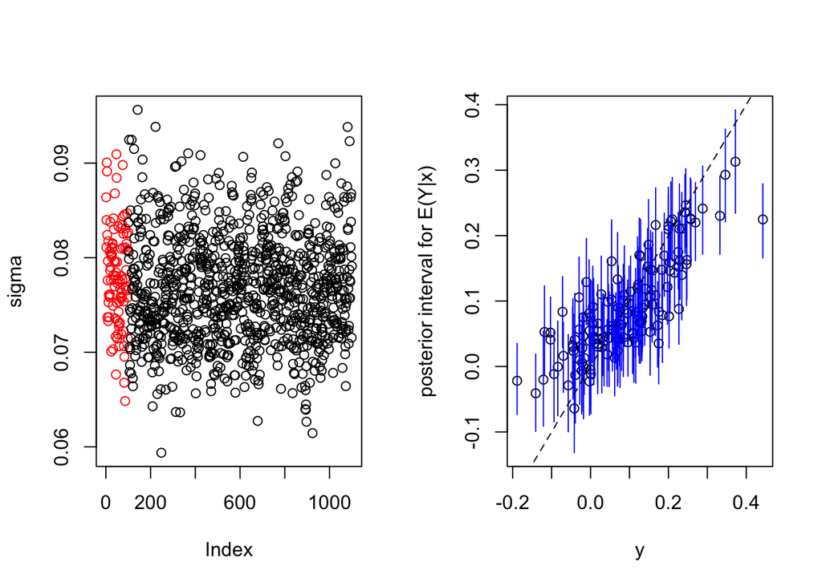

```r
plot(fit_bart)
```

If you look at the help page for `bart()` you’ll notice that we can’t directly specify a lot of the algorithm arguments that we can for the other tree functions. We *can* control these parameters through the choice of priors that we impose on the model. To take advantage of the additive nature of random forests, we want to choose priors that give all variables a relatively equal chance of being chosen in a given subsample. If important variables can easily overwhelm others, they will be present in almost all iterations, losing some of the power of ensemble methods. The weak uniform priors we want to specify are known as regularization priors in this context. The priors on the tree parameters $\Theta_m$ are fixed in the function, but we can change the parameters on the prior for the error variance $\sigma$. We specify this prior through the `sigdf` and `sigquant` arguments.

Before we start tweaking these prior parameters, we need to make sure we can make predictions to assess predictive fit. Unlike the other tree functions, `bart` objects do *not* have a `predict()` method. Instead, we need to supply the test data when we run the function. We can then access the predicted values from the `bart` fit object. Try tweaking some of the prior parameter values and the number of trees to grow to see how this affects the MSE of our Bayesian forest.

```r
fit_bart <- bart(x.train = votes_train[, 2:ncol(votes_train)],
                 y.train = votes_train[, 1],
                 x.test = votes_test[, 2:ncol(votes_train)], sigdf = 5,
                 sigquant = .7, k = 2.5, ntree = 500, nskip = 100)
mse(fit_bart$yhat.test.mean, votes_test$beta_exp)
```

[output not shown]

## Model Comparison

One of the ways we can assess the accuracy of a given tree based model is comparing its predictive fit with other alternatives. An advantage of this approach is that we can compare between ensembles generated from the same method with different parameters, as well as across ensembles resulting from different methods. Calculate the MSE for your fits from each of the methods we’ve explored and compare them.

```r
mse_tree <- mse(pred_tree, votes_test$beta_exp)
mse_rpart <- mse(pred_rpart, votes_test$beta_exp)
mse_rf <- fit_rf$mse[length(fit_rf$mse)]
mse_gbm <- mse(votes_test$beta_exp, pred_gbm)
mse_bart <- mse(fit_bart$yhat.test.mean, votes_test$beta_exp)

mse_comp <- t(data.frame(tree = mse_tree, rpart = mse_rpart,
                         randomforest = mse_rf, gbm = mse_gbm,
                         bart = mse_bart))
colnames(mse_comp) <- 'MSE'
options(digits = 4)
kable(mse_comp)
```

|  | MSE |
| --- | --- |
| tree | 0.0095 |
| rpart | 0.0112 |
| randomforest | 0.0078 |
| gbm | 0.0080 |
| bart | 0.0089 |

```r
options(digits = 2)
```

## Model Interpretation and Quantities of Interest

Machine learning methods are frequently criticized due to their black box nature, which can inhibit our ability to uncover the relationship between predictors and outcomes. Much of the machine learning literature focuses on feature selection, or trying to identify which predictors contribute the most explanatory power to the model. However, these can be very complicated, and often don’t tell us much about the direction of a predictor’s effect on the outcome.

One simple approach is to treat $f(x)$ the same way we do with generalized linear models when we want to generate quantities of interest. Pick one of your ensemble fits (`randomForest` or `gbm` will be easier than BART since they have `predict()` methods and won’t require you to re-estimate the fit). Generate simulated data profiles that vary direct tax revenus from the minimum to maximum observed values while holding all other predictors at their mean, minimum, and maximum. Generate predicted `beta_exp` values of the effect of income on turnout for these data, and then plot all three together. This is called a partial dependence plot in the machine learning literature

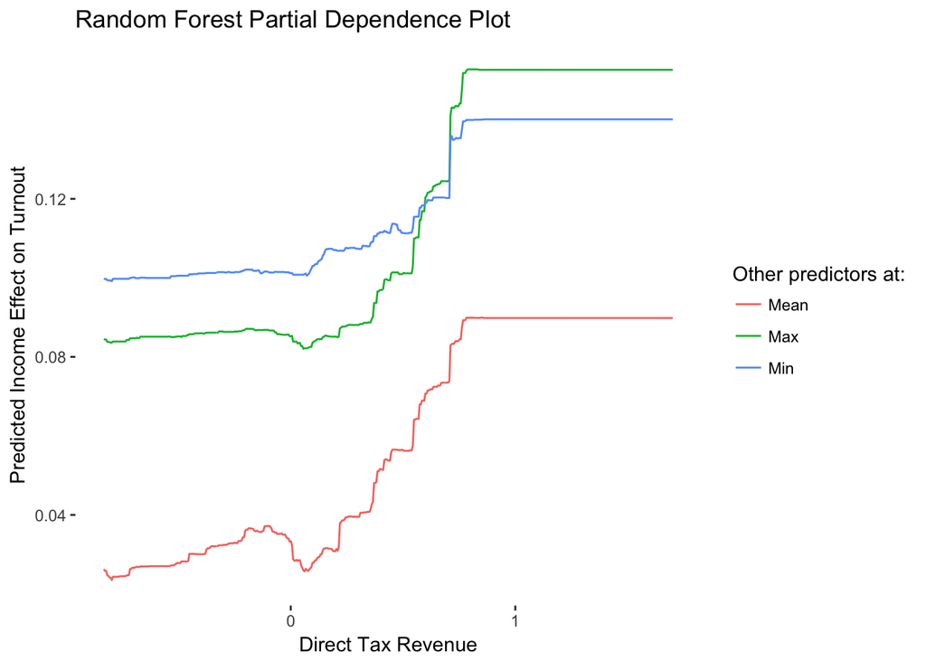

```r
# get sequence of alcohol b/w observed min/max
tax_seq <- seq(min(votes$dtax_per_rev_z), max(votes$dtax_per_rev_z),
                  length.out = 500)

# predicted probabilities at mean
votes_sim <- votes[, -1]
votes_sim <- apply(votes_sim, 2, mean)
votes_sim <- matrix(rep(votes_sim, 500), nrow = 500, byrow = T)
votes_sim[, 6] <- tax_seq
pred_sim_mean <- predict(fit_rf, votes_sim)
me_df <- data.frame(tax_seq = tax_seq, beta_mean = pred_sim_mean)

# predicted probabilities at max
votes_sim <- votes[, -1]
votes_sim <- apply(votes_sim, 2, max)
votes_sim <- matrix(rep(votes_sim, 500), nrow = 500, byrow = T)
votes_sim[, 6] <- tax_seq
pred_sim_max <- predict(fit_rf, votes_sim)
me_df$beta_max <- pred_sim_max

# predicted probabilities at min
votes_sim <- votes[, -1]
votes_sim <- apply(votes_sim, 2, min)
votes_sim <- matrix(rep(votes_sim, 500), nrow = 500, byrow = T)
votes_sim[, 6] <- tax_seq
pred_sim_min <- predict(fit_rf, votes_sim)
me_df $beta_min <- pred_sim_min

# convert to long to plot each prediction separately
me_df <- melt(me_df, id.vars = 'tax_seq')

# plot
ggplot(data = me_df, aes(x = tax_seq, y = value, color = variable)) +
  geom_line() +
  theme_bw() +
  ggtitle('Random Forest Partial Dependence Plot') +
  labs(x = 'Direct Tax Revenue', y = 'Predicted Income Effect on Turnout') +
  scale_color_discrete(name = 'Other predictors at:',
                       labels = c('Mean', 'Max', 'Min')) +
  theme_rw()
```

As with most things, someone’s written a package to make this easier. We can use the `pdp` package to easily create partial dependence plots from many different types of machine learning models.

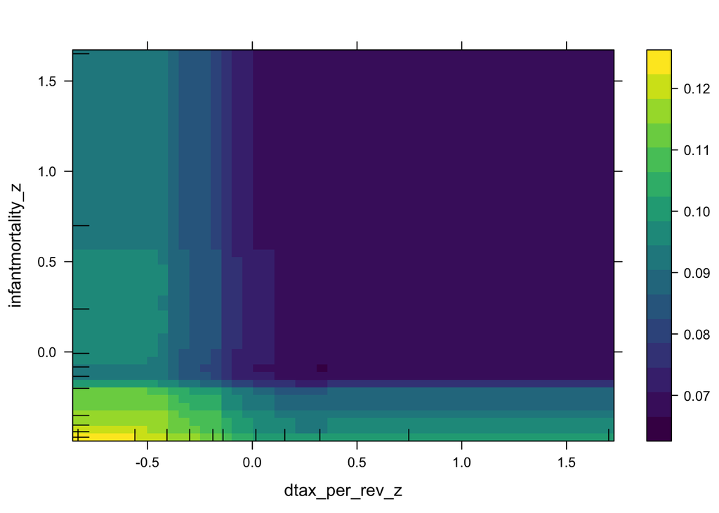

```r
library(pdp) # partial dependence plots
library(doParallel) # parallel processing

# register parallel backend
registerDoParallel(makeCluster(parallel::detectCores()))

# create partial dependence object for gbm
gbm_part <- partial(fit_gbm, pred.var = c('dtax_per_rev_z', 'infantmortality_z'),
                   train = votes_train, rug = T,
                   n.trees = which(gbm_mse_seq == min(gbm_mse_seq)))

# plot of partial dependence
plotPartial(gbm_part, train = votes_train, rug = T)
```

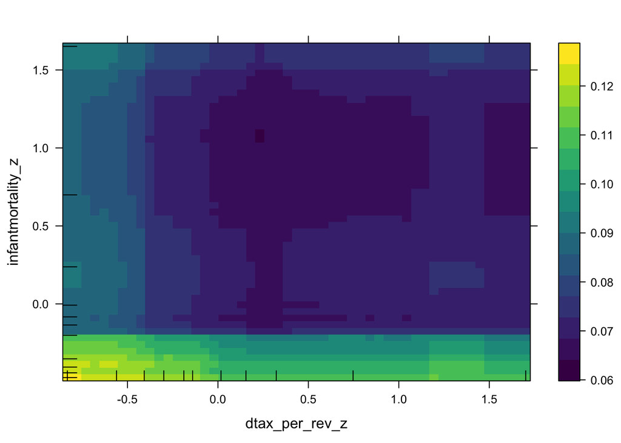

```r
# create partial dependence object for rf; need to export package used to create model in parallel
rf_part <- partial(fit_rf, pred.var = c('dtax_per_rev_z', 'infantmortality_z'),
                   train = votes_train, rug = T, parallel = T,
                   paropts = list(.packages = "randomForest"))

# lattice plot of partial dependence
plotPartial(rf_part, train = votes_train, rug = T)
```

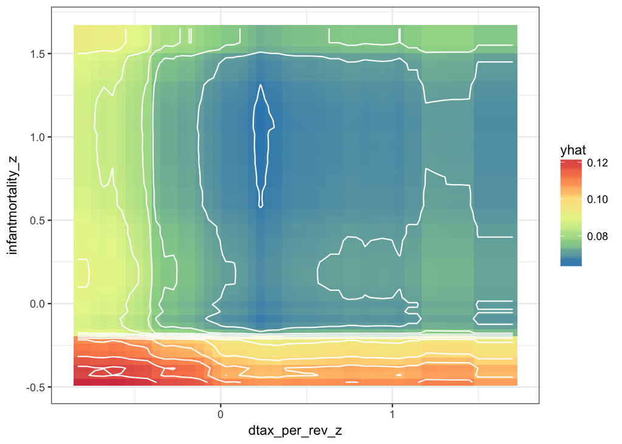

```r
# fancy ggplot of partial dependence
autoplot(rf_part, train = votes_train, contour = T, rug = T)
```

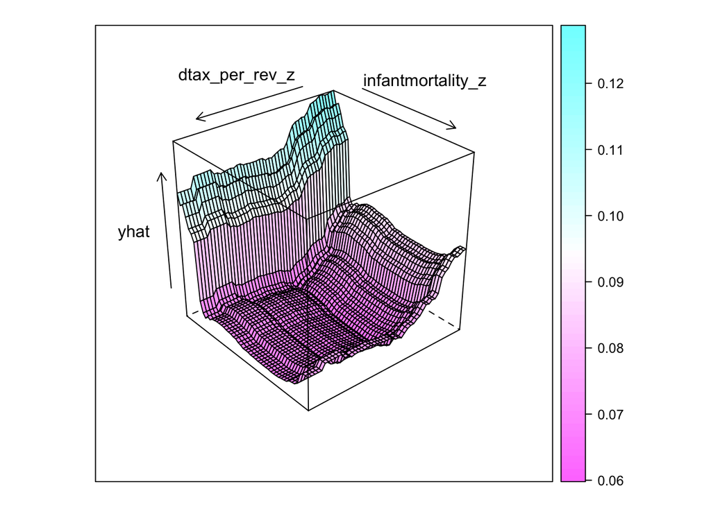

```r
# 3D plot of partial dependence
plotPartial(rf_part, levelplot = F, drape = T, screen = list(z = 220, x = -60))
```

The plots for our `randomForest` and `gbm` models are pretty similar, and overall there’s not a lot of meaningful difference between them. It looks like direct tax revenue might have a slightly negative relationship with the effect of income on probability of voting, which is the opposite of what the original paper finds. Let’s investigate this closer. Create a new partial dependence object, but this time set the `ice` argument to true, which will produce individual expectation curves, which show how our model would predict the outcome for each country in our training data.

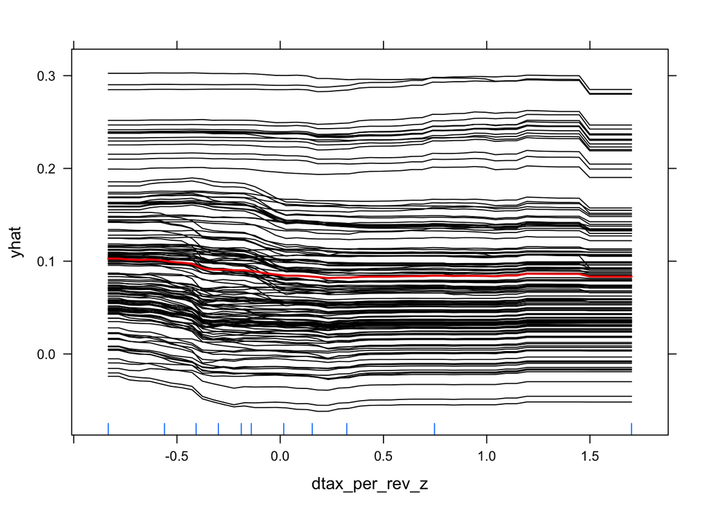

```r
# partial dependence object for just one predictor; generate ICE curves
rf_part <- partial(fit_rf, pred.var = 'dtax_per_rev_z',
                   train = votes_train, rug = T,
                   ice = T,
                   parallel = T,  paropts = list(.packages = "randomForest"))

# plot ICE curves and average partial dependence
plotPartial(rf_part, train = votes_train, rug = T)
```

It looks like there’s a somewhat negative relationship here, but only for cases in the lower portion for direct tax revenue in our sample. This is the opposite of the relationship that the authors find in the original paper. It could be that testing all six explanatory varaibles simultaneously would have revealed the same result. However, remember when I told you that $\beta_j$ had non-random measurement error, and that you shouldn’t average imputed datasets? We can’t draw any valid conclusions from this analysis because we’ve neglected two serious sources of uncertainty and variance in these analyses.

## Individual Exercise

In addition to regression trees, we can also fit classification trees when we have binary or categorical outcomes. Use `fl2003.RData`, which is a subset of the data in Fearon and Laitin (2003), and the package of your choice, to fit an ensemble model that explains `onset` as a function of all other variables. Determine the most important variables in the ensemble, and then produce a partial dependence plot showing the relationship between two variables that are *not* the most important, and the predicted probability of civil war in a given observation. Discuss this relationship.

# References

Fearon, James D., and David D. Laitin. 2003. “Ethnicity, Insurgency, and Civil War.” *The American Political Science Review* 97 (1): 75–90.

Kasara, Kimuli, and Pavithra Suryanarayan. 2015. “When Do the Rich Vote Less Than the Poor and Why? Explaining Turnout Inequality Across the World.” *American Journal of Political Science* 59 (3): 613–27.

[^1]: The dependent variable in these data, `beta_exp`, is the coefficient estimate from a logistic regression of the effect of income on the probability of voting, estimated separately for each country using individual level survey data. As such, there is inherent uncertainty around each $\beta_j$. The original paper accounts for this by treating each $\beta_j$ as a draw from a $\mathcal{N}(\beta_j,\sigma_j)$ distribution. This lab does not do this.
[^2]: I’ve multiply imputed these data due to missingness on some predictors, and then averaged the imputed datasets. Don’t do this; if you don’t remember why, come talk to me.